# Ecuador Trust Index

Summary

13 June, 2024

EN

ES

This page presents additional analysis of survey data collected by the Ecuadorian Red Cross (ERCS) in end of 2023, covering questions around trust as part of the Community Trust Index project.

# Sampling

The survey is based on a convenient sampling approach focused on large parts of the country in Ecuador. Out of 2317 participants, 2099 individuals agreed to answer the questionnaire and acknowledged that they were adults. In the following study, only adults respondents have been considered.

## Coverage

The survey was conducted in all provinces (24) and 97 cantons (see map). The graph below shows the distribution of respondents by province and compares it with the actual distribution of the population of each province in order to estimate the geographical representativeness.

[interactive chart not shown]

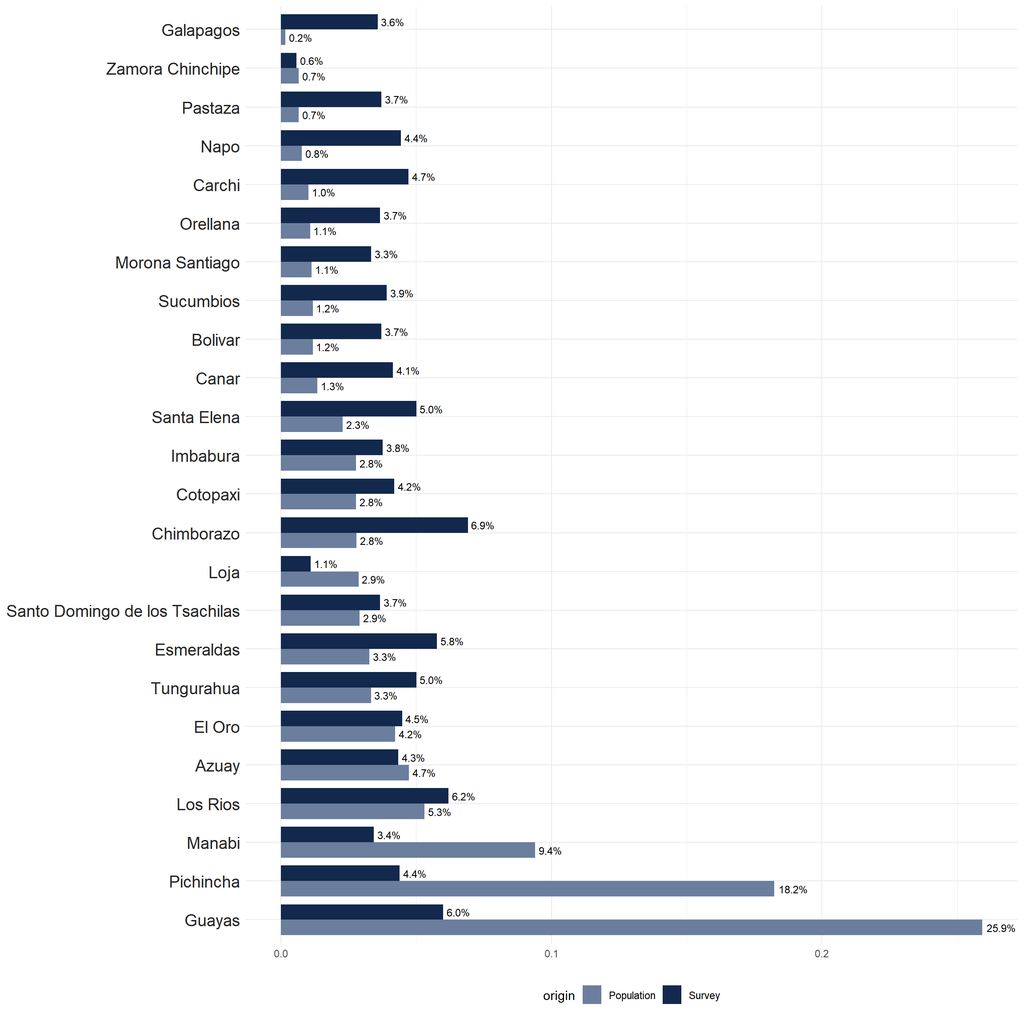

## Gender and age group

The following data shows the breakdown of the sample by gender and age. The male/female ratio of the sample (0.92) shows a slight over-representation of females compared to the national population distribution in Ecuador (0.99).

| Demographic | Total | Female | Male | Other response |
| --- | --- | --- | --- | --- |
| Respondents | 2099 | 1083 | 1000 | 16 |

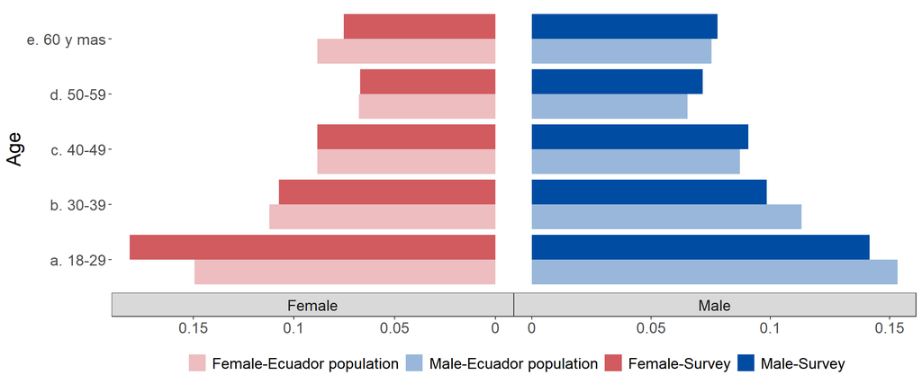

The breakdown by age and gender shows a statistical over-representation of women aged 18-29 and, to a lesser extent, of men aged 40-49 and 50-59. Conversely, women over 60 and men aged 18-29 are under-represented.

## Education level

The breakdown of the sample by level of education shows an over-representation of people who have followed a higher education course (complete or incomplete). Conversely, respondents with only primary education are under-represented.

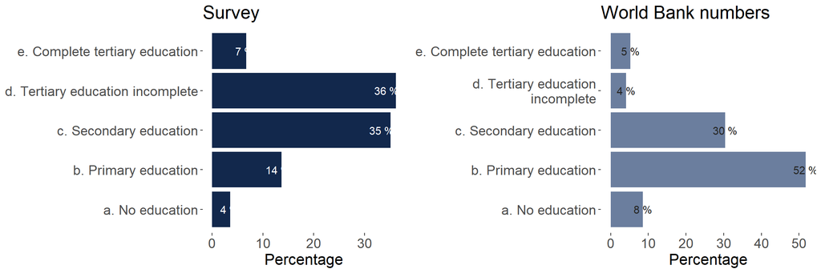

## Employment

The sample’s demographic composition on employments status seems to indicate that people interviewed have a much higher rate of unemployment than the average of the country, which had an unemployment rate of 4.6% in 2016 and labor force participation rate of 68.5% in the same year according to the World Bank data.

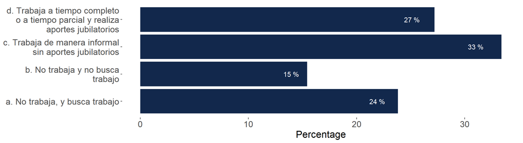

## Relationship with Red Cross

To better understand community trust, we identified previous relationships with the Ecuadorian Red Cross. In Ecuador, we distinguished between people who had previously received assistance from the Red Cross (referred to here as ‘beneficiaries’) and those who had never received assistance (referred to as ‘others’). This study did not focus on Red Cross volunteers.

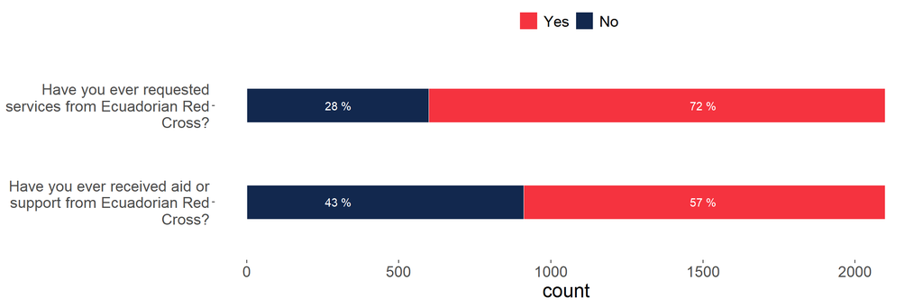

# Results

## Scores distribution

*Distribution of mean scores for values and competencies per demographic questions*

To calculate the score, we divide the sum of all responses by the number of responses using a response scale ranging from 0 (Not at all) to 3 (Completely yes). Finally, the score is normalized on a scale of 0 to 10, where 0 represents the lowest score and 10 represents the highest score.

The raw scores (without weighting) for the socio-demographic factors and for the “Competencies” and “Values” variables are presented below.

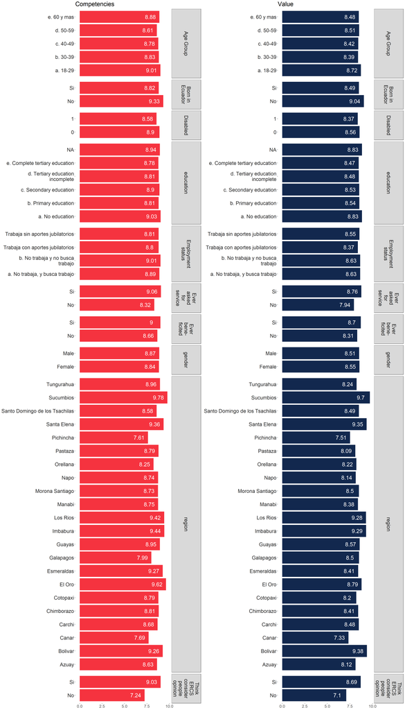

The analysis of the data indicates a significant difference between the groups of ‘Beneficiaries’ and ‘Others’ in terms of both competencies and values.

Geographically, there is also variation observed between provinces. For “Competencies”, the provinces of Pichincha, Cañar, Galapagos and Orellana present the lowest scores for Competencies, while the provinces of Pichincha, Cañar, Azuay, Pastaza, Napo, Cotopaxi and Orellana have a lower level of perception for Values.

Upon analysing the scores in relation to place of birth, we observe that migrants have a higher level of trust in the Ecuador Red Cross compared to individuals born in Ecuador, in both competencies and values. This may be due to the fact that migrants have also received assistance from the Red Cross.

*Note: There are not significant variations in the results based on age, gender, education level, employment status.*

## Weighting

To address the deviation of demographic parameters from the overall population, we have utilized a technique called raking. The raking process adjusts the results based on several variables to ensure that our sample reflects the distribution of these variables in the overall population. Here are the variables we considered for raking:

- Age groups and gender: We used UN data to determine the proportions of different age groups and gender in the population.
- Provinces: We used 2022 on population per province from the National Institute of Statistics and Censuses
- Students: we used 2020 data on student population from the National Institute of Statistics and Censuses

Using an appropriate package in R to conduct the raking, we obtained the following results.

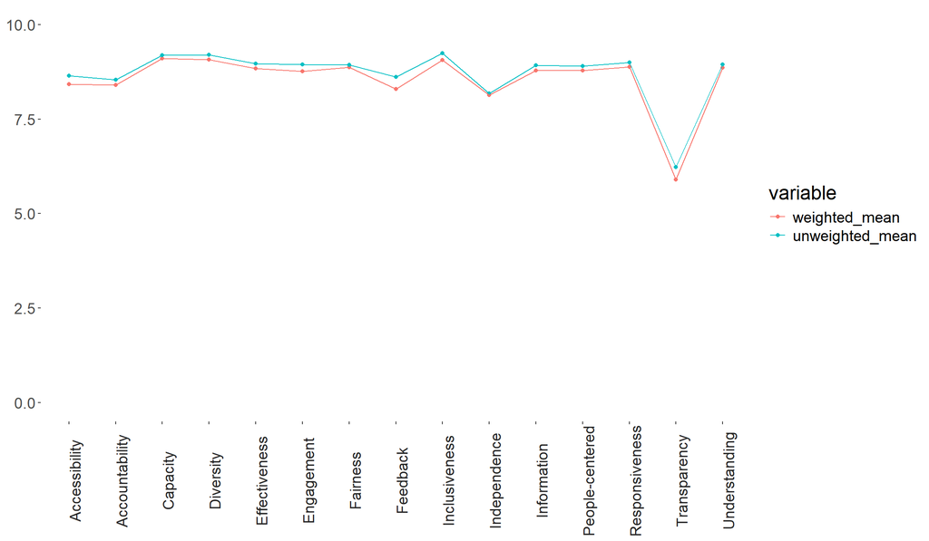

## Weighted Results

Here we are presenting the weighted data obtained through the raking process, which takes into account the variables gender, age groups, province, and educational level.

The analysis of the weighted average of the different sub-dimensions of trust shows that the score for “competencies” is slightly higher (8.74 out of 10) than the score for “values” (8.38 out of 10).

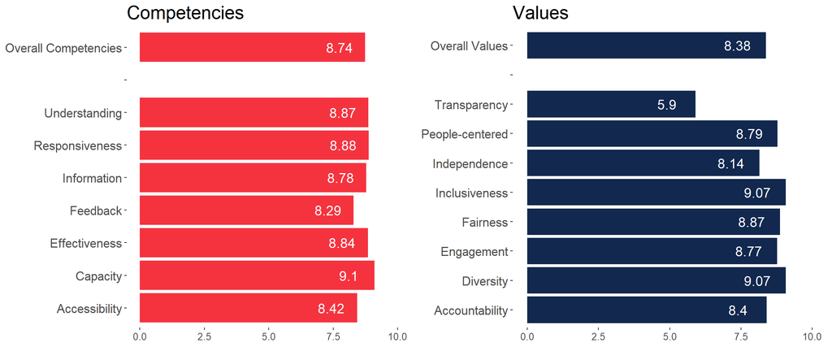

## Results per groups

When examining the sub-groups of ‘participants’, it is evident that individuals who have received assistance from the ERCS provide the most positive feedback compared to the other group. Perception of people who received assistance from ERCS are consistently higher than those of the other group across all questions. However, the question related to transparency received a very low rating from individuals who have never received support from the Red Cross.

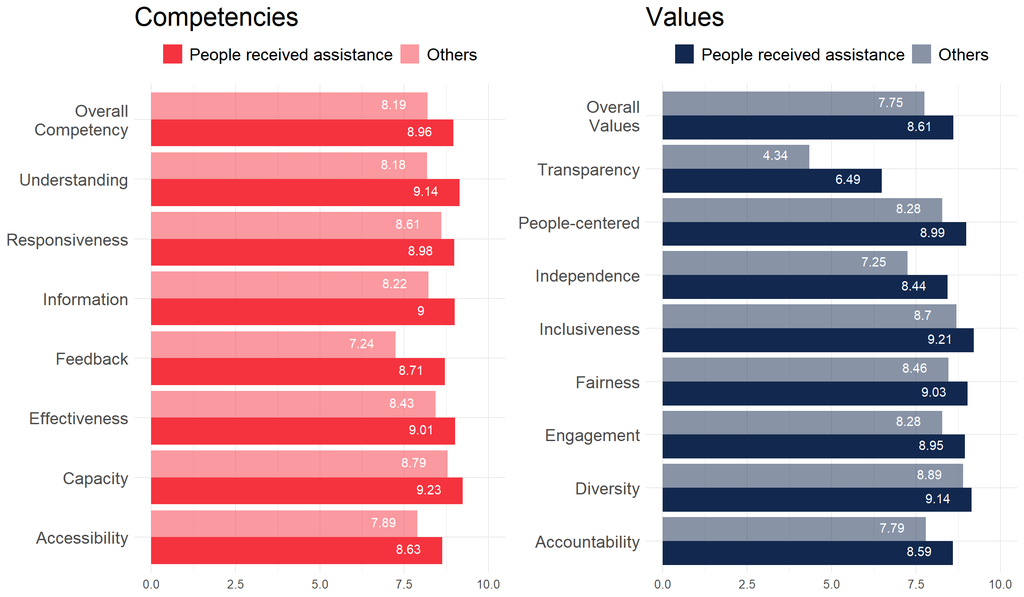

Download Summary Excel File